# Abgabe Gruppe C

## Optimierung mit Kostenfunktion

```r
pred_class <- function(x, threshold){
  ifelse(x < threshold,0,1)
}

cost <- function(prob, actual,threshold2, cost_FN_func, cost_FP_func){
    predicted_automate2 <- pred_class(prob,threshold2)
    count_FN <- sum(predicted_automate2 == 0 & actual == "1")
    count_FP <- sum(predicted_automate2 == 1 & actual == "0")
    cost <- count_FN * cost_FN_func + count_FP * cost_FP_func
    return (cost)
}

threshold_input_rdf <- c(0.05, 0.1, 0.14, 0.15, 0.16, 0.17, 0.18, 0.19,
                         0.2, 0.23, 0.24, 0.25, 0.29, 0.292874,
                         0.3, 0.35, 0.45, 0.7)

i <- 1
costs_rdf <- c()
cost_FN <- 3000
cost_FP <- 500

while (i < length(threshold_input_rdf)+1) {
    costs_rdf[[(length(costs_rdf) +1)]] <- cost(test_asdf$prob,
                                                test_asdf$EmployeeChurned,
                                                threshold_input_rdf[i], cost_FN, cost_FP)
    i <- i+1
}

cost_rdf_matrix <- matrix(c(threshold_input_rdf,costs_rdf),nrow=length(threshold_input_rdf))
colnames(cost_rdf_matrix) <- c("Threshold", "Kosten in Euro")
cost_rdf_matrix
```

```
##       Threshold Kosten in Euro
##  [1,] 0.05      245500
##  [2,] 0.1       248000
##  [3,] 0.14      241000
##  [4,] 0.15      242500
##  [5,] 0.16      239500
##  [6,] 0.17      237500
##  [7,] 0.18      233500
##  [8,] 0.19      243000
##  [9,] 0.2       251500
## [10,] 0.23      261500
## [11,] 0.24      273500
## [12,] 0.25      272000
## [13,] 0.29      311500
## [14,] 0.292874  324000
## [15,] 0.3       333500
## [16,] 0.35      420000
## [17,] 0.45      609000
## [18,] 0.7       1015000
```

Mit Betrachtung der Kosten liegt der optimale Threshold für das Model bei 0,18.

## Modellgüte mit optimiertem Threshold anhand der Konfusionsmatrix bestimmen

```r
threshold_glm_opti <- 0.18
test_asdf$predict_opti <-classify(test_asdf$prob, threshold_glm_opti)
confusionMatrix(factor(test_asdf$predict_opti), factor(test_asdf$EmployeeChurned),
                positive = "1")
```

```
## Confusion Matrix and Statistics
##
##           Reference
## Prediction   0   1
##          0 184  14
##          1 383 382
##
##                Accuracy : 0.5877
##                  95% CI : (0.5559, 0.619)
##     No Information Rate : 0.5888
##     P-Value [Acc > NIR] : 0.5399
##
##                   Kappa : 0.2535
##
##  Mcnemar's Test P-Value : <2e-16
##
##             Sensitivity : 0.9646
##             Specificity : 0.3245
##          Pos Pred Value : 0.4993
##          Neg Pred Value : 0.9293
##              Prevalence : 0.4112
##          Detection Rate : 0.3967
##    Detection Prevalence : 0.7944
##       Balanced Accuracy : 0.6446
##
##        'Positive' Class : 1
##
```

## Wichtigkeit der Features

```r
varimp_glm <- h2o.varimp(best_glm)
varimp_glm
```

```
## Variable Importances:
##                          variable relative_importance scaled_importance
## 1                      Paybands.A            6.956101          1.000000
## 2         decrease_Category.Other            3.278105          0.471256
## 3 decrease_Category.GB Management            3.180520          0.457227
## 4        decrease_Category.Safety            1.609598          0.231394
## 5         development to exempt.1            1.326404          0.190682
##   percentage
## 1   0.266451
## 2   0.125567
## 3   0.121829
## 4   0.061655
## 5   0.050807
##
## ---
##                                 variable relative_importance scaled_importance
## 38                      Part Time Mark.0            0.019239          0.002766
## 39                      Part Time Mark.1            0.009553          0.001373
## 40 Vertical_Horizontal_Developments.>= 3            0.000000          0.000000
## 41        start_contract type.apprentice            0.000000          0.000000
## 42                start_Part time mark.0            0.000000          0.000000
## 43               development to exempt.0            0.000000          0.000000
##    percentage
## 38   0.000737
## 39   0.000366
## 40   0.000000
## 41   0.000000
## 42   0.000000
## 43   0.000000
```

# Support Vecto Machine

## Datenimport und Vorbereitung

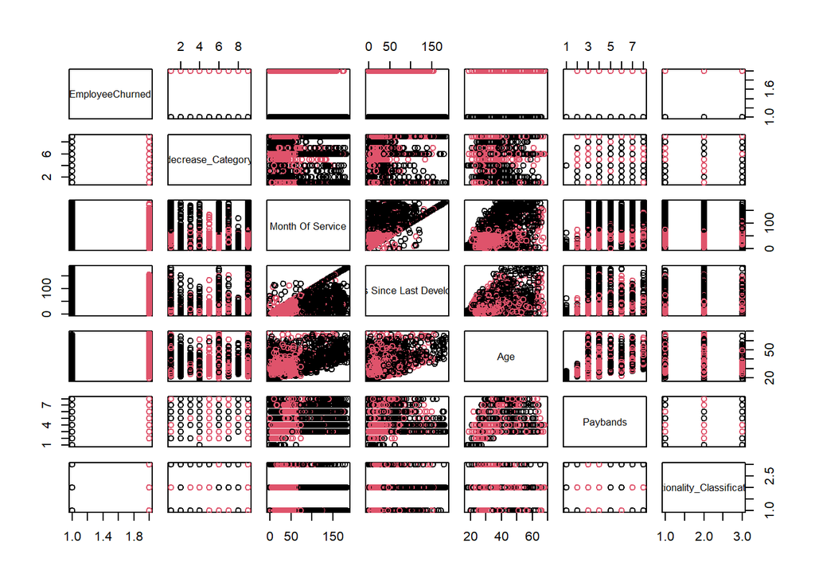

```r
df_svm <- read_xlsx("20220110_dataPrepped_beforeOneHot.xlsx")

# Kategorische Variablen umwandeln
factorCols <- c("EmployeeChurned",
                "decrease_Category",
                "Nationality_Classification",
                "Paybands")

df_svm %<>% mutate_at(factorCols, factor)
# Auswählen der zu nutzenden Spalten auf Grund der Ergebnisse von Random Forrest, die Nutzung aller Features ist mit einem sehr hohen Rechenaufwand verbunden, der nicht geleistet werden konnte.
df_svm <- subset(df_svm, select = c(EmployeeChurned, decrease_Category, `Month Of Service`, `Months Since Last Development`, Age, Paybands, Nationality_Classification))

# Ansehen der Daten
plot(df_svm, col=df_svm$EmployeeChurned)
```

## Erstellen der Train und Test Datensets

```r
data_test <- subset(hot_df, select = c("EmployeeChurned", "Age", "Month Of Service"))
df_test <- data.frame(data_test)
n <- nrow(df_test)

train_indices <- sample(1:n, round(2/3 * n))
train <- df_test[train_indices,]
test <- df_test[-train_indices,]

# erstmal 2 Features auswählen
features <- c("Age", "Month.Of.Service")
cols <- c(features, "EmployeeChurned")
```

## SVM

```r
# erstmal 2 Features auswählen
features <- c("Age", "Month.Of.Service")
cols <- c(features, "EmployeeChurned")

# fit an SVM with linear kernel
svmfit <- svm(EmployeeChurned ~ ., data = train[,cols], kernel = "linear",
              cost = 1, scale = TRUE)

# information about the model including the support vectors
summary(svmfit)
```

```
##
## Call:
## svm(formula = EmployeeChurned ~ ., data = train[, cols], kernel = "linear",
##     cost = 1, scale = TRUE)
##
##
## Parameters:
##    SVM-Type:  C-classification
##  SVM-Kernel:  linear
##        cost:  1
##
## Number of Support Vectors:  1967
##
##  ( 990 977 )
##
##
## Number of Classes:  2
##
## Levels:
##  0 1
```

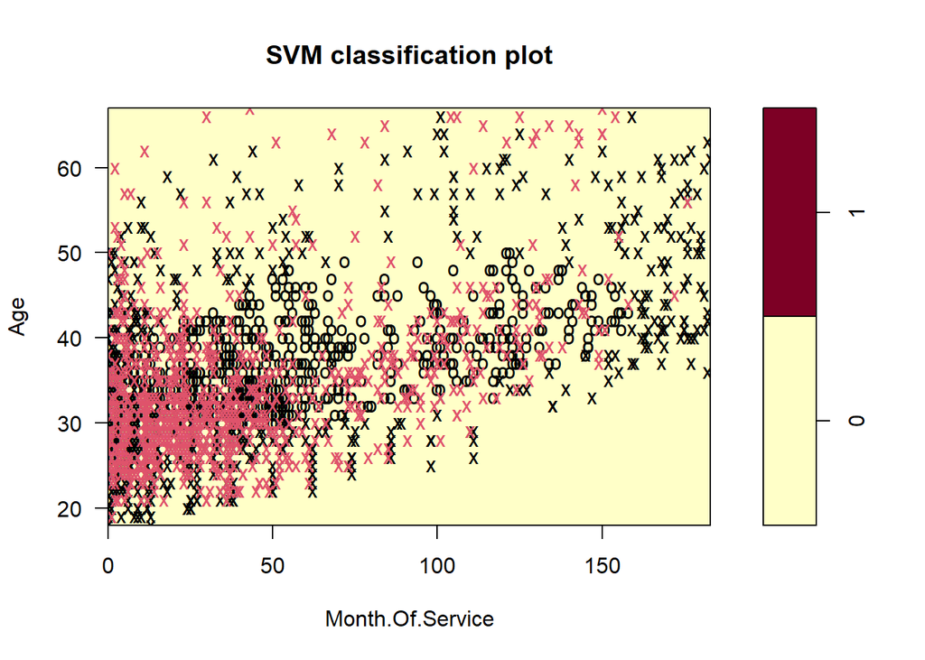

```r
# plot it including the separation lines (hyperplanes)
plot(svmfit, train[,cols])
```

```r
# predict on the test data set
prediction <- predict(svmfit, test, type = "class")

# confusion matrix with quality measures
confusionMatrix(prediction, test[,"EmployeeChurned"])
```

```
## Confusion Matrix and Statistics
##
##           Reference
## Prediction   0   1
##          0 814 476
##          1   0   0
##
##                Accuracy : 0.631
##                  95% CI : (0.604, 0.6574)
##     No Information Rate : 0.631
##     P-Value [Acc > NIR] : 0.5125
##
##                   Kappa : 0
##
##  Mcnemar's Test P-Value : <2e-16
##
##             Sensitivity : 1.000
##             Specificity : 0.000
##          Pos Pred Value : 0.631
##          Neg Pred Value :   NaN
##              Prevalence : 0.631
##          Detection Rate : 0.631
##    Detection Prevalence : 1.000
##       Balanced Accuracy : 0.500
##
##        'Positive' Class : 0
##
```

Wir erkennen sowohl an der Confusions Matrix, als auch am Plot, dass die svm Methode hier nicht zum Erfolg führt, da alle Predictions 0 sind. Dies wird an der Art unserer Daten liegen und wie das Data Frame nach dem One-Hot-Encoding aufgebaut ist. Daher haben wir uns entschieden auf das H2O-Paket umzusteigen, welches selbst die Daten richtig aufbereitet und wir die Rohdaten nutzen konnten.

Wir haben bewusst nicht alle Features betrachtet, da nicht alle Merkmale einen signifikanten Einfluss haben. Mehr wollten wir auf den Ergebnissen der anderen Methoden aufbauen und ermitteln, ob wir eine noch bessere Vorhersage mit der Support-Vector-Machine erreichen können. Des Weiteren stand uns nicht genügend Rechenkraft zur Seite beim Tuning um alle Features zu berücksichtigen.

## H2O Vorbereitung und Umwandlung der Daten

```r
df_svmH2O <- as.h2o(df_svm)
#in H2o Test und Train erzeugen, da sonst keine validen Ergebnisse
splits <- h2o.splitFrame(data =  df_svmH2O, ratios = 0.75, seed = 1234)
trainH2O_svm <- splits[[1]]
testH2O_svm <- splits[[2]]

target <- "EmployeeChurned"
# erstmal 2 Features auswählen die die stärkste Abhängikeit nach den Trees haben
predictors <- c( "decrease_Category", "Month Of Service")
```

## SVM mit H2O

```r
#https://docs.h2o.ai/h2o/latest-stable/h2o-docs/data-science/svm.html
#SVM durchführen
svm_model <- h2o.psvm(
  rank_ratio = 0.1,
  y ="EmployeeChurned",
  training_frame = trainH2O_svm,
  disable_training_metrics = FALSE
  )
#svm auf Testdatensatz testen
svm_model_h20 <- h2o.getModel(svm_model@model_id)
perf_svm <- h2o.performance(svm_model_h20, testH2O_svm)
perf_svm
```

```
## H2OBinomialMetrics: psvm
##
## MSE:  0.3987539
## RMSE:  0.6314696
## LogLoss:  NaN
## Mean Per-Class Error:  0.4052629
## AUC:  NaN
## AUCPR:  NaN
## Gini:  NaN
##
## Confusion Matrix (vertical: actual; across: predicted) for F1-optimal threshold:
##          0   1    Error      Rate
## 0      358 209 0.368607  =209/567
## 1      175 221 0.441919  =175/396
## Totals 533 430 0.398754  =384/963
##
## Maximum Metrics: Maximum metrics at their respective thresholds
##                         metric threshold      value idx
## 1                       max f1  1.000000   0.535109   0
## 2                       max f2  1.000000   0.548659   0
## 3                 max f0point5  1.000000   0.522212   0
## 4                 max accuracy  1.000000   0.601246   0
## 5                max precision  1.000000   0.513953   0
## 6                   max recall  1.000000   0.558081   0
## 7              max specificity  1.000000   0.631393   0
## 8             max absolute_mcc  1.000000   0.187539   0
## 9   max min_per_class_accuracy  1.000000   0.558081   0
## 10 max mean_per_class_accuracy  1.000000   0.594737   0
## 11                     max tns  1.000000 358.000000   0
## 12                     max fns  1.000000 175.000000   0
## 13                     max fps  1.000000 209.000000   0
## 14                     max tps  1.000000 221.000000   0
## 15                     max tnr  1.000000   0.631393   0
## 16                     max fnr  1.000000   0.441919   0
## 17                     max fpr  1.000000   0.368607   0
## 18                     max tpr  1.000000   0.558081   0
##
## Gains/Lift Table: Extract with `h2o.gainsLift(<model>, <data>)` or `h2o.gainsLift(<model>, valid=<T/F>, xval=<T/F>)`
```

Die H20.psvm Methode führt eine svm aus und legt zusätzlich alle Informationen in das Model wie zum Beispiel die Confusions Matrix. Darüber hinaus wurde das Model auf den Testdatensatz angewendet. Das Ergebnis ist eine durchschnittlicher Error von ca. 40%. Dies ist wesentlich weniger als 50% und damit besser als raten (50%). Jedoch ist es noch weit entfernt von einer Vorhersage, die wir uns wünschen. Wir hätten gern wie beim DRF eine Optimierung der Parameter “Gamma” und “Cost” vorgenommen, nur leider ist dies in der H2O Bibliothek nicht möglich. Dies haben wir daher mit der e1071 Bibliothek realisiert, da wir rausgefunden haben, dass diese wieder anwendbar ist, nachdem umwandeln der der Daten von H20 und wieder zurück in ein “normales” DataFrame.

## SVM Tune Funktion mit e1071

Folgend verwenden wir die Tune Funktion um das beste “Gamma” und “Cost” zu ermitteln für eine optimale Vorhersage.

```r
# Umwandeln der H20 DataFrames in "normale" DataFrames, um das Tuning der e1071 Methode ausführen können.
tunedf_svm <- as.data.frame(df_svmH2O)
trainDF_svm <- as.data.frame(trainH2O_svm)
testDF_svm <- as.data.frame(testH2O_svm)

#Tuning der Parameter -> hier hätten wir gern eine größere Bandbreite an gamma und cost Variablen durchlaufen lassen, wurde aber von unserer Rechenleistung nicht gewährleistet. Daher haben wir in einzelnen Schritten uns den jetztigen WErten angenähert um so einen möglichst optimalen Wert zu finden. Auch ist zu ebachten, dass wir keinen Gamma-Wert unter 0.01 nutzen konnten, da diese nicht mehr von den folgenden Methoden unterstützt werden.

tuneSVM <- function(svm_type) {

     tuned_svm <- tune(svm, EmployeeChurned ~ .,
              data = trainDF_svm,
              kernel = svm_type,
              scale = TRUE,
              ranges = list(cost = c(0.05, 0.075),  gamma = c(0.01, 0.02,0.25)),
              tunecontrol = tune.control(cross=5)
              )
    tuned_svm

    # train on the entire data set using best value for cost
    best_cost <- as.numeric(tuned_svm$best.parameters[1])
    print(paste0("Cost: ", best_cost))

    best_gamma <- as.numeric(tuned_svm$best.parameters[2])
    print(paste0("Gamma: ", best_gamma))

    svmfit_best <- svm(EmployeeChurned ~ .,
                  data = trainDF_svm,
                  kernel = svm_type,
                  cost = best_cost,
                  gamma = best_gamma,
                  scale = TRUE)
  return(svmfit_best)
}
```

## Linear SVM

```r
linear_svm <- tuneSVM("linear")
```

```
## [1] "Cost: 0.075"
## [1] "Gamma: 0.01"
```

```r
#plot(linear_svm, trainDF_svm[,cols])
#Leider ist die Plotfunktion nicht mehr möglich nach dem umwandeln der Daten in H20 und wieder zurück

#predict
prediction_linear <- predict(linear_svm, testDF_svm, type = "class")

# confusion matrix with quality measures
confusionMatrix(prediction_linear, testDF_svm[, "EmployeeChurned"])
```

```
## Confusion Matrix and Statistics
##
##           Reference
## Prediction   0   1
##          0 465 218
##          1 102 178
##
##                Accuracy : 0.6677
##                  95% CI : (0.637, 0.6974)
##     No Information Rate : 0.5888
##     P-Value [Acc > NIR] : 2.839e-07
##
##                   Kappa : 0.2821
##
##  Mcnemar's Test P-Value : 1.287e-10
##
##             Sensitivity : 0.8201
##             Specificity : 0.4495
##          Pos Pred Value : 0.6808
##          Neg Pred Value : 0.6357
##              Prevalence : 0.5888
##          Detection Rate : 0.4829
##    Detection Prevalence : 0.7092
##       Balanced Accuracy : 0.6348
##
##        'Positive' Class : 0
##
```

## Radial SVM

```r
radial_svm <- tuneSVM("radial")
```

```
## [1] "Cost: 0.075"
## [1] "Gamma: 0.25"
```

```r
#predict
prediction_radial <- predict(radial_svm, testDF_svm, type = "class")

# confusion matrix with quality measures
confusionMatrix(prediction_radial, testDF_svm[, "EmployeeChurned"])
```

```
## Confusion Matrix and Statistics
##
##           Reference
## Prediction   0   1
##          0 515 284
##          1  52 112
##
##                Accuracy : 0.6511
##                  95% CI : (0.62, 0.6812)
##     No Information Rate : 0.5888
##     P-Value [Acc > NIR] : 4.252e-05
##
##                   Kappa : 0.2096
##
##  Mcnemar's Test P-Value : < 2.2e-16
##
##             Sensitivity : 0.9083
##             Specificity : 0.2828
##          Pos Pred Value : 0.6446
##          Neg Pred Value : 0.6829
##              Prevalence : 0.5888
##          Detection Rate : 0.5348
##    Detection Prevalence : 0.8297
##       Balanced Accuracy : 0.5956
##
##        'Positive' Class : 0
##
```

## SVM mit besten Parametern

Für H2O nutzen wir die ermittelten Gamma Werte von Linear, da diese ein höhere Accuracy haben.

```r
#https://docs.h2o.ai/h2o/latest-stable/h2o-docs/data-science/svm.html
#SVM durchführen
svm_model <- h2o.psvm(
  hyper_param = 0.075,
  gamma = 0.01,
  rank_ratio = 0.1,
  y ="EmployeeChurned",
  training_frame = trainH2O_svm,
  disable_training_metrics = FALSE
  )
# mehr Infos über Model und support Vektoren
summary(svm_model)
```

```
## Model Details:
## ==============
##
## H2OBinomialModel: psvm
## Model Key:  PSVM_model_R_1643552598170_19440
## Model Summary:
##   number_of_support_vectors number_of_bounded_support_vectors
## 1                      2168                              1994
##   raw_model_size_in_bytes      rho number_of_iterations surrogate_gap
## 1                  112736 -0.25657                   77       0.00002
##   primal_residual dual_residual
## 1         0.00000       0.00014
##
## H2OBinomialMetrics: psvm
## ** Reported on training data. **
## ** Training metrics **
##
## MSE:  0.3668273
## RMSE:  0.6056627
## LogLoss:  NaN
## Mean Per-Class Error:  0.4005157
## AUC:  NaN
## AUCPR:  NaN
## Gini:  NaN
##
## Confusion Matrix (vertical: actual; across: predicted) for F1-optimal threshold:
##           0    1    Error        Rate
## 0      1337  512 0.276906   =512/1849
## 1       554  503 0.524125   =554/1057
## Totals 1891 1015 0.366827  =1066/2906
##
## Maximum Metrics: Maximum metrics at their respective thresholds
##                         metric threshold       value idx
## 1                       max f1  1.000000    0.485521   0
## 2                       max f2  1.000000    0.479687   0
## 3                 max f0point5  1.000000    0.491499   0
## 4                 max accuracy  1.000000    0.633173   0
## 5                max precision  1.000000    0.495567   0
## 6                   max recall  1.000000    0.475875   0
## 7              max specificity  1.000000    0.723094   0
## 8             max absolute_mcc  1.000000    0.200776   0
## 9   max min_per_class_accuracy  1.000000    0.475875   0
## 10 max mean_per_class_accuracy  1.000000    0.599484   0
## 11                     max tns  1.000000 1337.000000   0
## 12                     max fns  1.000000  554.000000   0
## 13                     max fps  1.000000  512.000000   0
## 14                     max tps  1.000000  503.000000   0
## 15                     max tnr  1.000000    0.723094   0
## 16                     max fnr  1.000000    0.524125   0
## 17                     max fpr  1.000000    0.276906   0
## 18                     max tpr  1.000000    0.475875   0
##
## Gains/Lift Table: Extract with `h2o.gainsLift(<model>, <data>)` or `h2o.gainsLift(<model>, valid=<T/F>, xval=<T/F>)`
##
##
##
## NULL
```

```r
#svm auf Testdatensatz testen
best_svm_model_h20 <- h2o.getModel(svm_model@model_id)
best_perf_svm <- h2o.performance(best_svm_model_h20, testH2O_svm)
best_perf_svm
```

```
## H2OBinomialMetrics: psvm
##
## MSE:  0.384216
## RMSE:  0.6198516
## LogLoss:  NaN
## Mean Per-Class Error:  0.4054834
## AUC:  NaN
## AUCPR:  NaN
## Gini:  NaN
##
## Confusion Matrix (vertical: actual; across: predicted) for F1-optimal threshold:
##          0   1    Error      Rate
## 0      405 162 0.285714  =162/567
## 1      208 188 0.525253  =208/396
## Totals 613 350 0.384216  =370/963
##
## Maximum Metrics: Maximum metrics at their respective thresholds
##                         metric threshold      value idx
## 1                       max f1  1.000000   0.504021   0
## 2                       max f2  1.000000   0.486039   0
## 3                 max f0point5  1.000000   0.523385   0
## 4                 max accuracy  1.000000   0.615784   0
## 5                max precision  1.000000   0.537143   0
## 6                   max recall  1.000000   0.474747   0
## 7              max specificity  1.000000   0.714286   0
## 8             max absolute_mcc  1.000000   0.193381   0
## 9   max min_per_class_accuracy  1.000000   0.474747   0
## 10 max mean_per_class_accuracy  1.000000   0.594517   0
## 11                     max tns  1.000000 405.000000   0
## 12                     max fns  1.000000 208.000000   0
## 13                     max fps  1.000000 162.000000   0
## 14                     max tps  1.000000 188.000000   0
## 15                     max tnr  1.000000   0.714286   0
## 16                     max fnr  1.000000   0.525253   0
## 17                     max fpr  1.000000   0.285714   0
## 18                     max tpr  1.000000   0.474747   0
##
## Gains/Lift Table: Extract with `h2o.gainsLift(<model>, <data>)` or `h2o.gainsLift(<model>, valid=<T/F>, xval=<T/F>)`
```